# data-exploration

Willem van de Merbel

2026-03-18

# Data exploration & Explanation

This project starts with the download of two raw datasets produced by Yelp. These datasets are called users.csv and tips.csv and are downloaded from Google drive for easy access.

## Introduction to the data set & data cleaning notes

The raw dataset (`users.csv`) was first filtered to retain only observations corresponding to restaurants. This was done by identifying entries in the `categories` variable that contain the term “Restaurants”. Additionally, observations without a recorded price range (`RestaurantsPriceRange2`) were removed to ensure consistency in subsequent analyses.

Next, relevant attributes were extracted from the semi-structured `attributes` column using regular expressions. These attributes include service-related characteristics such as delivery, takeout, reservations, and table service (see table below for the full list and operationalisation). The extracted variables were grouped conceptually into delivery-related features (e.g., delivery, takeout, drive-thru) and dine-in features (e.g., reservations, outdoor seating, table service).

To facilitate quantitative analysis, boolean attributes originally stored as `"True"` and `"False"` were converted into numeric indicators (1 and 0). The `price_range` variable was extracted and converted to a numeric format. The `Alcohol` attribute was also cleaned and recoded into categorical levels (`none`, `beer_and_wine`, and `full_bar`).

Observations with missing values for `price_range` were removed during the cleaning process. Before merging the datasets, missing values in aggregated variables such as tip compliment counts were replaced with zero to reflect the absence of recorded compliments rather than missing information.

To capture the extent of service offerings, two composite variables were constructed. The `delivery_score` represents the sum of delivery-related services, while the `dinein_score` represents the sum of dine-in related services. These variables provide a concise measure of how many services each restaurant offers in each category.

Finally, the cleaned restaurant dataset was merged with the tips dataset using `business_id` as a key. Tip-level data was aggregated to the restaurant level by summing the `compliment_count` variable. The resulting datasets were saved at different stages of the pipeline, including `restaurants_clean.csv`, `restaurants_attributes_extracted.csv`, and `restaurants_merged.csv`.

## Important variables and their operationalisation

| **Variable** | **Description** | **Operationalisation** | **Role** |
| --- | --- | --- | --- |
| stars | Average Yelp rating of the restaurant | Numeric value from 1–5 based on Yelp reviews | Dependent variable |
| RestaurantsDelivery | Whether the restaurant offers delivery | Binary variable (1 = delivery available, 0 = no delivery) | Delivery cluster |
| RestaurantsTakeOut | Whether takeout is available | Binary variable (1 = takeout available, 0 = not available) | Delivery cluster |
| Caters | Whether catering services are offered | Binary variable (1 = yes, 0 = no) | Delivery cluster |
| DriveThru | Presence of drive-through service | Binary variable (1 = yes, 0 = no) | Delivery cluster |
| RestaurantsReservations | Whether reservations are accepted | Binary variable (1 = yes, 0 = no) | Dine-in cluster |
| RestaurantsGoodForGroups | Whether the restaurant is suitable for groups | Binary variable (1 = yes, 0 = no) | Dine-in cluster |
| Alcohol | Whether alcohol is served | Categorical variable indicating alcohol availability | Dine-in cluster |
| HappyHour | Whether the restaurant offers happy hour | Binary variable (1 = yes, 0 = no) | Dine-in cluster |
| OutdoorSeating | Whether outdoor seating is available | Binary variable (1 = yes, 0 = no) | Dine-in cluster |
| GoodForKids | Whether the restaurant is suitable for kids | Binary variable (1 = yes, 0 = no) | Dine-in cluster |
| RestaurantTableService | Whether table service is offered | Binary variable (1 = yes, 0 = no) | Dine-in cluster |
| price_range | Restaurant price category | Ordinal scale representing price levels (1 $ <–> 4 $$$$) | Moderator |

## Distributions

Before examining the relationship between variables, it is useful to first explore the distribution of the main varibales in the merged dataset. This gives a clearer overview of what the data looks like and helps assess whether certain values occur frequently or only rarely.

The dependent variable in this analysis is `stars`, which reflects the average Yelp rating of a restaurant on a scale from 1 to 5. Figure 1 shows that most restaurants are concnetrated between approximately 3 and 4.5 stars. The mean star rating is 3.46, with a standard deviation of 0.80, indicating that restaurants in the dataset generally receive moderately positive evaluations while still showing meaningful variation. THe distribution appears slightly left-skewed, meaning that lower ratings are relatively uncommon compared to mid-range and higher ratings. This is improtant because `stars`is the main outcome variable in the analysis, and understanding its distribution provides context for interrpeting the regression results later on.

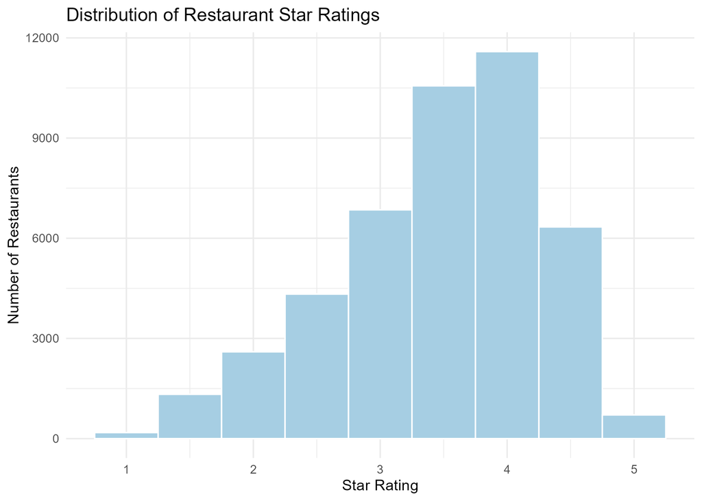

The moderator in this analysis is `price_range`, which captures the restaurant’s price category. Figure 2 shows that this variable is unevenly distributed across categories. Most restaurants fall into the lower price levels, especially categories 1 and 2, while categories 3 and 4 are much less common. This indicates that the sample is skewed toward lower-priced restaurants. Since `price_range` is later used as a moderator, this imbalance should be kept in mind when interpreting interaction effects, as the highest price categories are represented by fewer observations.

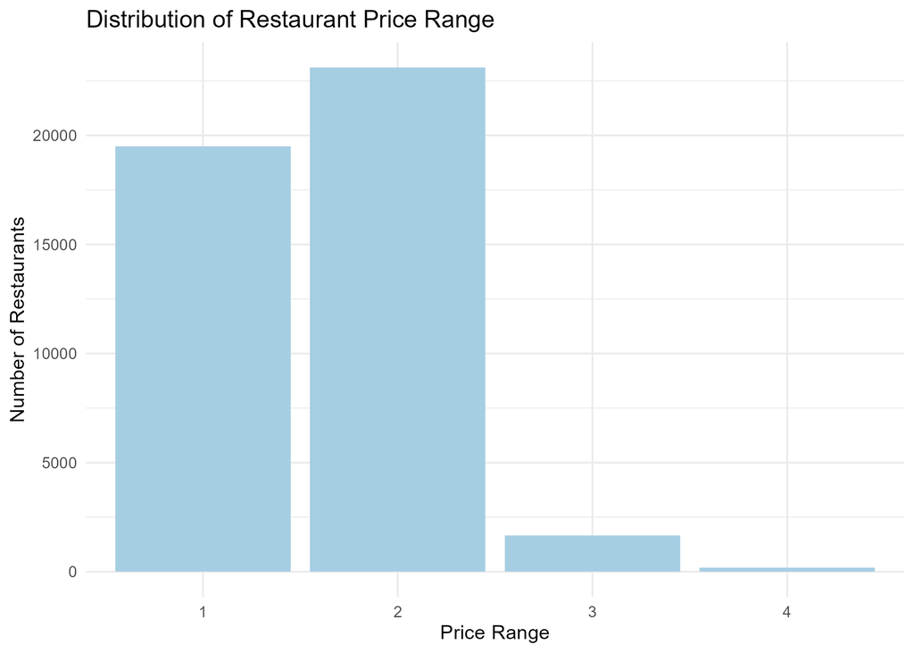

The constructed service variables, `delivery_score` and `dinein_score`, also show meaningful variation across restaurants. These variables summarize the number of delivery-related and dine-in-related services offered by a restaurant. `delivery_score` ranges from 0 to 4 with a mean of 1.93, while `dinein_score` ranges from 0 to 6 with a mean of 2.67. Figure 3 and 4 show that in both cases, most restaurants offer some services, but only a smaller subset offers a wide range of delivery or dine-in options. The histogram also shows that both variables are discrete rather than continous, which is expected because they are based on sums of binary indicators.

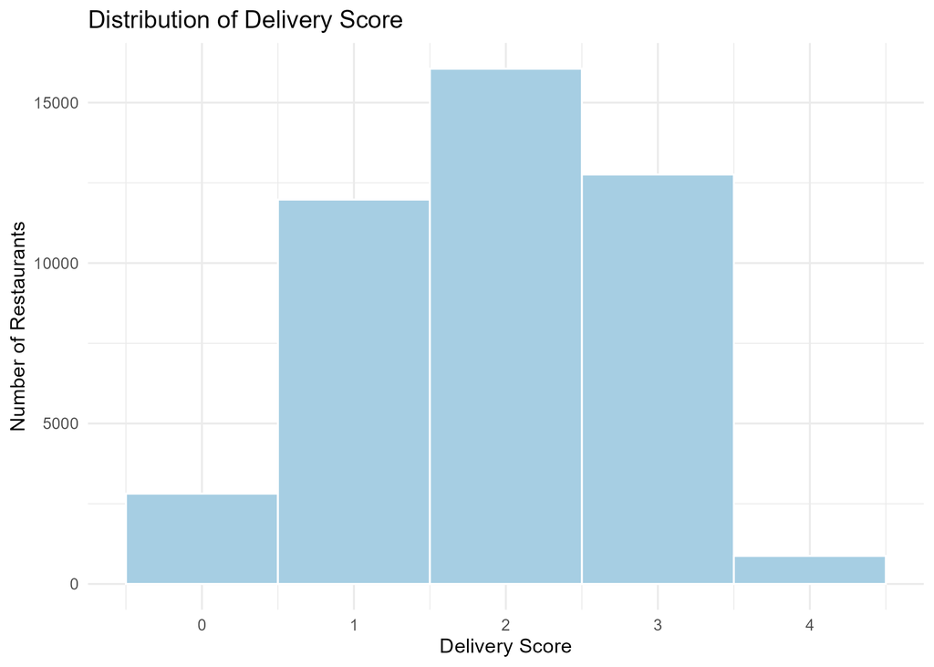

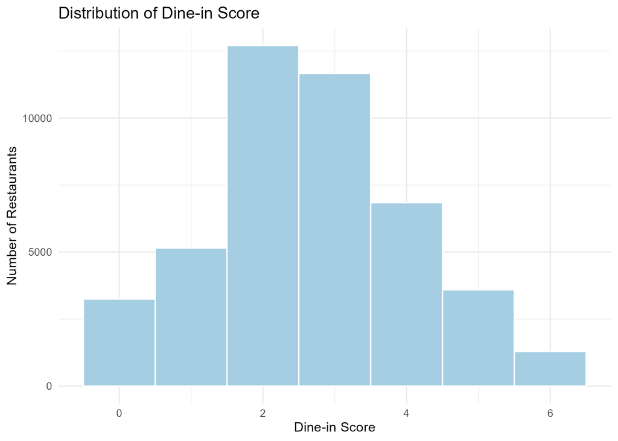

Taken together, these descriptive plots show that the dataset contain sufficient variation for further analysis, while also making clear that some variables, especially `price_range` are not evenly distributed across categories.

## Missing values (NA)

Missing values were partly addressed during the cleaning stage of the pipeline. Restaurants without a recorded `price_range` were removed from the dataset to ensure comparability across observations. As a result, the final anayltical dataset no longer contains missing values on this moderator.

For the service varibales extracted from the `attributes` column, the interpretation of missing variable is more nuanced. These variables were recoded into binary indicators based on whether a specific service was mentioned in the available restaurant information. In some cases, missing values may reflect that a service was not recorded rather than that it was definitely unavailable.

In the merged dataset, missing values for aggregated tip-related variables were handled differently. For instance, missing values in the summed tip compliment count were replaced by zero. This was a reasonable choice because the absence of recorded compliments is more approximately interpeted as none observed rather than as unknown information. This improves consistency in the merged restaurant-level dataset and avoids losing observations unnecessarily.

Overall, the treatment of missing variables depended on the meaning of the variable. Missing observations on an important moderator such as `price_range` were removed, while missing vlaues in count-based variables were, where appropriate, recoded to zero.

## Basic relations

After describing the main variables separately, the next step is to examine the basic relationship between the service variable and restaurant ratings. The following plots provide an intial visual impression of these associations

Figure 5 shows the relationship between `delivery_score` and `stars`. The fitted regression line slopes slightly downward, suggesting a negative association. This means that restaurant offering more delivery-related services tend to receive somewhat lower ratings on average. The corresponding simple linear regression confirms a small but statistically significant negative effect: a one-point increase in `delivery_score` is associated with a decrease of about 0.063 stars. At the same time, the explained variance is very low R-squared = 0.005, indicating that the practical importance of this relationship is limited.

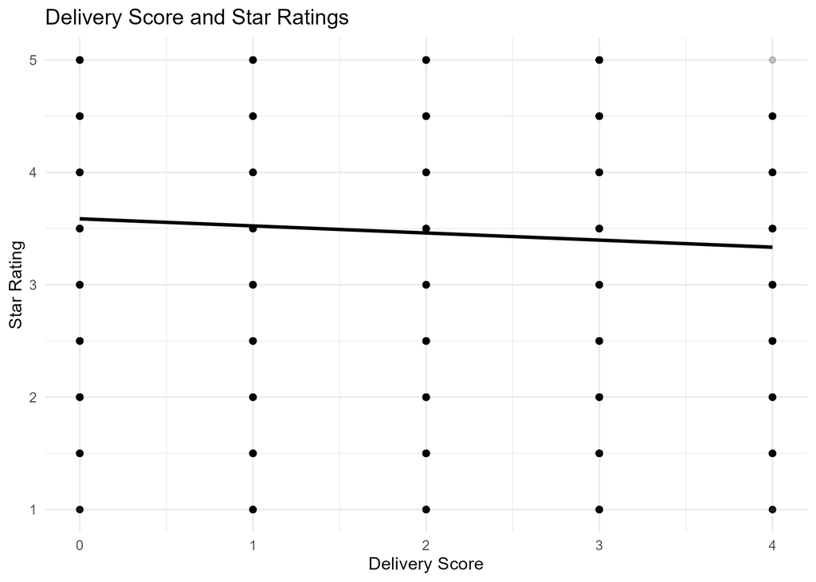

Figure 6, shows the relationship between `dinein_score`and `stars`. Here, the fitted regression line slopes upward, indicating a positive association. Restaurants that offer more dine-in-related services tend to receive somewhat higher ratings. This is consistent with the regression coefficient of about 0.097, which is statistically significant. The explained variance is still mdoest, but somewhat larger than in the delivery model with a r-sqaured of 0.029. This suggest that `dine-in features` may be more strongly related to customer evaluations than `delivery-related services`.

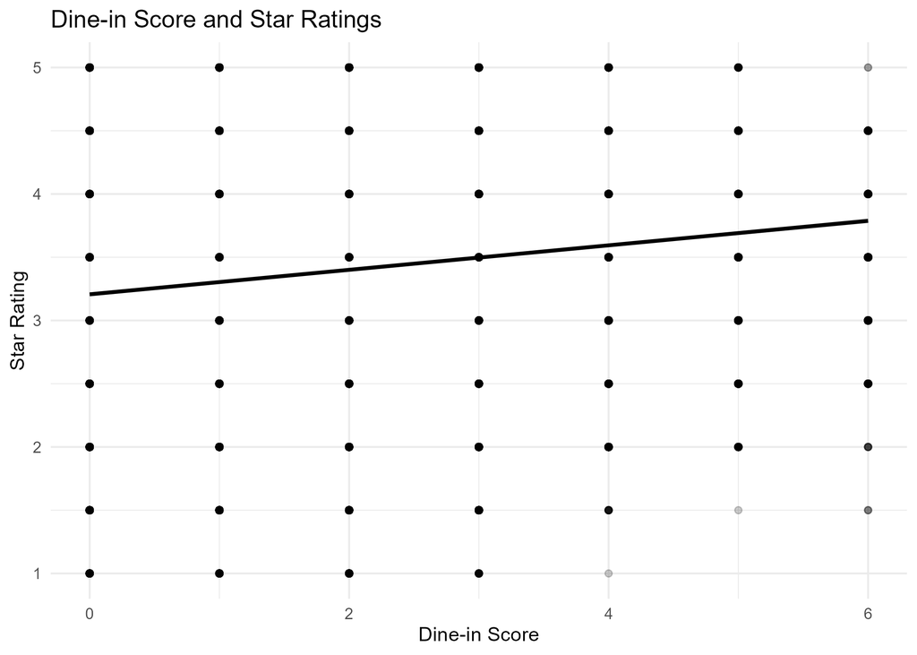

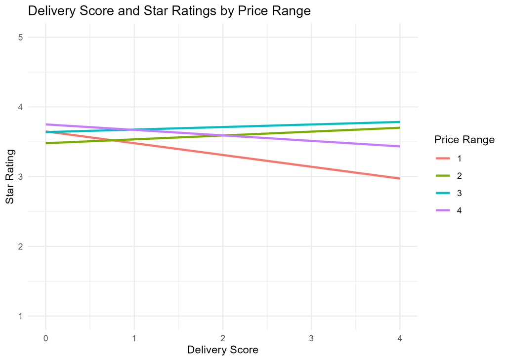

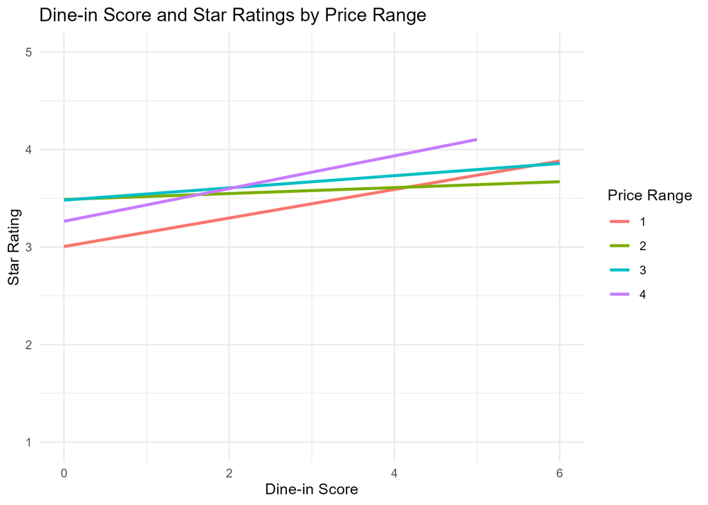

Taken together, the exploratory analysis suggests that delivery-ralted and dine-in-related services are associated with restaurant ratings in different ways. Delivery-related services show a slight negative association, while dine-in services show a clearer positive association. In addition, both relationships appear to vary across price levels, which suggests that the effect of service offerings may dpeend on restaurant price category.